# Using metabolomics for diagnosis and prognosis of Gastric Cancer

# Background / context

Data set from collection of liquid chromatography mass spectrometry (LC-MS)-based targeted metabolomics

The patient metabolome datafile includes 281 healthy normal patients and 145 patients that have been diagnosed with gastric cancers. In total 147 metabolites including amino acids, organic acids, nucleotides, nucleosides, vitamins, acylcarnitines, amines, and carbohydrates were measured and recorded

The cohort information is a datafile with information on the cohort of cancer patients in the patient metabolome and has information on the stage of their cancer

```r
# Patient metabolome datafile

patient_metabolome <- read.csv("https://raw.githubusercontent.com/VilcekSummerR/final-assignment-krutisutaria/Data_for_study/Gastric_cancer_metabolomic_data.csv")

cohort_information <- read.csv("https://raw.githubusercontent.com/VilcekSummerR/final-assignment-krutisutaria/Data_for_study/cohort_information.csv")
```

# Methods: Explore the data / clean the data

Ensured all the column names were properly descriptive of the data they measured. Noticed first column wasn’t properly named so added a descriptive name to it

Additionally, changed the designation of healthy and cancer patients in the data set (indicated by N and P, respectively) to more intuitive labels

Checked to see if there were any NAs in the dataset (there weren’t any in this dataset so didn’t need to have to consider removing any patients from the cohort)

```r
colnames(patient_metabolome)[1] <- "Batch_patient_ID"

num_na <- anyNA(patient_metabolome)

patient_metabolome <- patient_metabolome %>%
  mutate(type = recode(type,
                           "P" = "Cancer",
                           "N" = "Normal"))
```

# Methods: Combine multiple datasets

The stage of disease of cancer patients from the cohort information datafile is being added to the patient metabolome dataframe in column “stage_of_disease”

Because only cancer patients are in the cohort information, there are patient IDs rows in the metabolome dataframe that are not in the cohort information file. For patient IDs with no corresponding values in the cohort info file, the value in new column “stage_of_disease” will be “_No_cancer”

```r
# Adding new column to patient_metabolome with stage of disease for cancer patients and "_No_cancer" for healthy patients

patient_metabolome <- merge(patient_metabolome, cohort_information[,c("sample_id","stage")], by = "sample_id", all.x = TRUE)

# Renaming the 'stage' column to 'Stage_of_disease'

colnames(patient_metabolome)[which(names(patient_metabolome) == "stage")] <- "stage_of_disease"

# Replace NA values with '_No_cancer'

patient_metabolome$stage_of_disease[is.na(patient_metabolome$stage_of_disease)] <- '_No_cancer'


# Make copy of metabolome not scaled for relative gene expression analysis later in the workflow

original_patient_metabolome <- patient_metabolome
```

# Methods: Overview of patient cohorts in dataset

A summary table of number of patients in cohort by by stage of disease

```r
# Convert data frame to a data table

DT_patient_metabolome <- setDT(patient_metabolome)

stage_counts <- DT_patient_metabolome[, .N, by=stage_of_disease]
setnames(stage_counts, c("Stage of cancer", "Patient count"))

table1 <- datatable(stage_counts)

print(table1)
```

[output not shown]

# Methods: Combining patient cohorts to improve analysis

Because there are so few patients in the stage IA (45 patients) and IB (7 patients) of cancer, to increase strength of analysis in later comparison, I combine all patients in stage IA and IB to stage I

```r
patient_metabolome$stage_of_disease[patient_metabolome$stage_of_disease == "IA"] <- "I"

patient_metabolome$stage_of_disease[patient_metabolome$stage_of_disease == "IB"] <- "I"
```

# Methods: Normalizing data for analysis

Across 147 metabolites, there is a range of means and variances so needed to normalize the data (mean is equal to 0 and sd is 1). Created for loop to normalize columns with values of the expression of 147 metabolites

Split data set into one dataframe for cancer patients and another for healthy patients to enable seamless calculations

```r
# Scaling columns with numeric values of the metabolites to have mean equal to 0 and standard deviation equal to 1

numeric_columns <- sapply(patient_metabolome, is.numeric)

for (i in 1:length(numeric_columns)) {
  if (numeric_columns[[i]]==TRUE) {
    value <- patient_metabolome[[i]]
    normalize_col <- (value - mean(value))/sd(value)
    patient_metabolome[[i]] <- normalize_col
  }
}

# Splitting patient dataframe into two. One dataframe for cancer patients and another dataframe for normal patients

cancer_metabolome <- patient_metabolome %>% filter(type == "Cancer")
healthy_metabolome <- patient_metabolome %>% filter(type == "Normal")
```

# Results: Identify statistically significant metabolites

Running Wilcoxon rank-sum test to find statistically significant metabolomes between the gastric cancer and non gastric cancer control groups

Out of the 147 metabolites measured, there are 96 metabolites that are significantly different between cancer and healthy patients

```r
# Isolating the numeric columns (columns containing values for the metabolome measurements) for cancer and normal patient dataframes

num_cols_cancer_metabolome <- cancer_metabolome %>%
  select_if(is.numeric)

num_cols_healthy_metabolome <- healthy_metabolome %>%
  select_if(is.numeric)

# Finding the mean of all metabolomes in cancer patients vs normal patients

cancer_metabolome_mean <- colMeans(num_cols_cancer_metabolome, na.rm = TRUE)

healthy_metabolome_mean <- colMeans(num_cols_healthy_metabolome, na.rm = TRUE)

# Next step is to add means of the cancer and non-cancer group to a summary dataframe

metabolome_summary <- cancer_metabolome_mean
metabolome_summary <- rbind(metabolome_summary, healthy_metabolome_mean)

rownames(metabolome_summary) <- c("cancer_metabolome_mean","health_metabolome_mean")

# Calculating the Wilcoxon rank-sum test for each metabolite across the cancer and non-cancer group

p_values <- numeric()

col_test <- names(num_cols_cancer_metabolome)

for (col in col_test){
  wilcox <- wilcox.test(num_cols_cancer_metabolome[[col]],num_cols_healthy_metabolome[[col]])
  p_values <- c(p_values, wilcox$p.value)
}

#Add p-values of metabolites to the summary dataframe

metabolome_summary <- rbind(metabolome_summary, p_values)

# Counting the number of metabolites that are significantly different between cancer and normal patients

sig_metabolites <- sum (p_values <0.01)

print(sig_metabolites)
```

```
## [1] 96
```

# Results: Evaluate mean of 10 most statistically significant metabolites

Looking at box-plot of 10 most significantly different metabolites (metabolites where the Wilcoxon rank sum test yielded the lowest values)

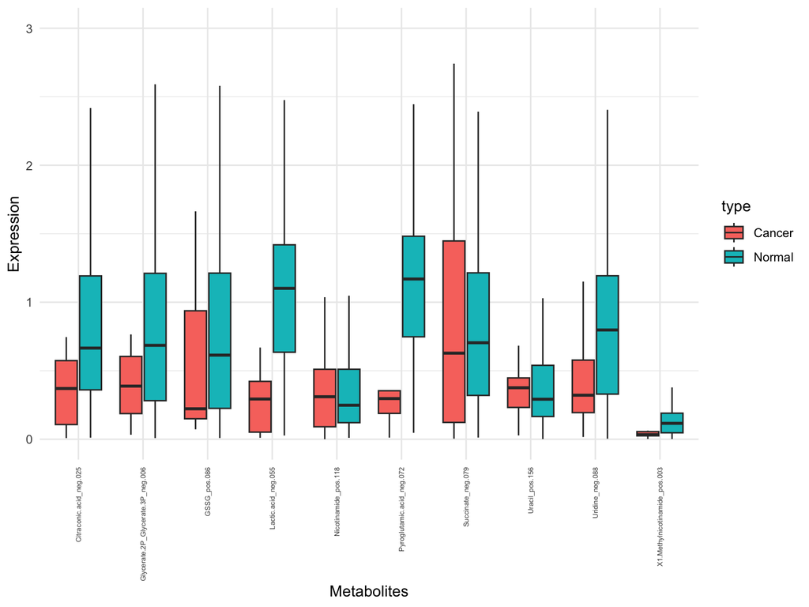

```r
# Find metabolites that have the lowest p values

p_values_extract <- metabolome_summary["p_values",]
ordered_metabolites <- names(p_values_extract)[order(p_values_extract)]

# Convert from wide to long format for genes with lowest 10 P values

metabolites_long <- patient_metabolome %>%
  pivot_longer(
    cols = c(ordered_metabolites[1:10]),
    names_to = "Metabolites",
    values_to = "Expression"
  )

# Making a box plot of metabolites with most significant difference in expression between gastric cancer patients and healthy patients

ggplot(metabolites_long, aes(x = Metabolites, y = Expression, fill = type)) +
  geom_boxplot(outlier.shape= NA) +
  labs(Title = "Boxplot of metabolites", x = "Metabolites", y="Expression") +
  theme_minimal() +
  theme(axis.text.x = element_text(angle = 90, vjust =0.5, hjust = 1, size = 5)) +
  ylim(0,3)+
  theme(plot.title = element_text(hjust = 0.5))
```

# Results: Identify overexpressed & underexpressed metabolites in gastic cancer patients vs healthy patients

There are certain metabolites that will be over or under expressed in cancer patients vs normal patients

This is calculated by taking the quotient of the average expression level of a gene for cancer patients and average expression level for normal patients (have to use the original data, not the z-transformed data)

If the fold change is greater than 1.25, the metabolite is considered to be overexpressed in cancer patients and if the fold change is less than 0.75, then gene is underexpressed

There are 22 metabolites that are overexpressed and 19 metabolites that are underexpressed

Relative metabolite expression values and categorical labels are added to the summary metabolite dataframe for further analysis

```r
# Split original data into cancer and healthy patients

cancer_metabolome_og <- original_patient_metabolome %>% filter(type == "Cancer")
healthy_metabolome_og <- original_patient_metabolome %>% filter(type == "Normal")

# Create for loop that goes through all the numeric rows of the dataframe (which are all the columns with metabolite expression data) and takes the quotient of mean expression of metabolites for cancer patients vs normal patients

relative_expression <- numeric()

for (i in 1:length(numeric_columns)) {
  if (numeric_columns[[i]]==TRUE) {
    mean_cancer <- mean(cancer_metabolome_og[[i]])
    mean_healthy <- mean(healthy_metabolome_og[[i]])
    relative_expression_difference <- mean_cancer / mean_healthy
    relative_expression <- rbind(relative_expression,relative_expression_difference)
  }
}

relative_expression <- as.vector(relative_expression)

metabolome_summary <- rbind(metabolome_summary, relative_expression)

# Tranform summary of metabolites to dataframe

df_metabolome_summary <- as.data.frame(t(metabolome_summary))

# Create new column in dataframe where metabolites are defined as overexpression, underexpression and no change by the fold change difference in expression between cancer vs non cancer patients

df_metabolome_summary$Expression_status <- ifelse(df_metabolome_summary$relative_expression > 1.25,
                                                  "Overexpression",
                                                  ifelse(df_metabolome_summary$relative_expression < 0.75,
                                                         "Underexpression",
                                                         "No change"))

# Finding the total number of metabolites that are overexpressed and underexpressed

count_overexpressed <- sum(df_metabolome_summary$Expression_status == "Overexpression")

count_underexpressed <- sum(df_metabolome_summary$Expression_status == "Underexpression")

print(paste0("Number of overexpressed metabolites: ",count_overexpressed))
```

```
## [1] "Number of overexpressed metabolites: 22"
```

```r
print(paste0("Number of underexpressed metabolites: ",count_underexpressed))
```

```
## [1] "Number of underexpressed metabolites: 19"
```

# Results: Comparing metabolite relative expression to significance of difference in expression

Creating scatterplot of metabolites by viewing relative expression of metabolites (mean cancer expression of metabolite divided by mean healthy patient expression) and the statistical significance in the difference between healthy and cancer patients

Downregulated metabolites appear to be more significantly different than upregulated metabolites in cancer patients

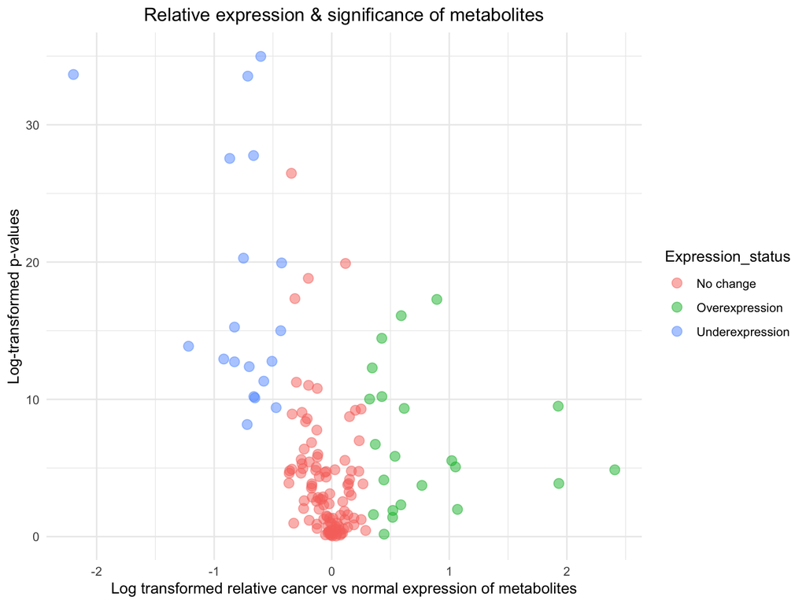

```r
#Log base 2 transform relative expression because range of values is too wide for visualization

df_metabolome_summary$log_relative_expression <- log2(df_metabolome_summary$relative_expression)

#Negative log base 10 transform p-value to "stretch out" p-values to really see which values are significant and which are not. Also want values that are higher on the y-axis to represent metabolites which are more significantly differentiated

df_metabolome_summary$log_p_values <- -log10(df_metabolome_summary$p_values)

# Creating scatterplot of metabolites based on p-value and relative expression

ggplot(df_metabolome_summary, aes(x= log_relative_expression, y = log_p_values, color = Expression_status))+
  geom_point(size=3, alpha = 0.5) +
  labs(title = "Relative expression & significance of metabolites",
       x = "Log transformed relative cancer vs normal expression of metabolites",
       y = "Log-transformed p-values") +
  theme_minimal() +
  theme(plot.title = element_text(hjust = 0.5))
```

# Results: Identification of 10 most overexpressed metabolites

Bubble plot of 10 most overexpressed metabolites in cancer vs healthy patients

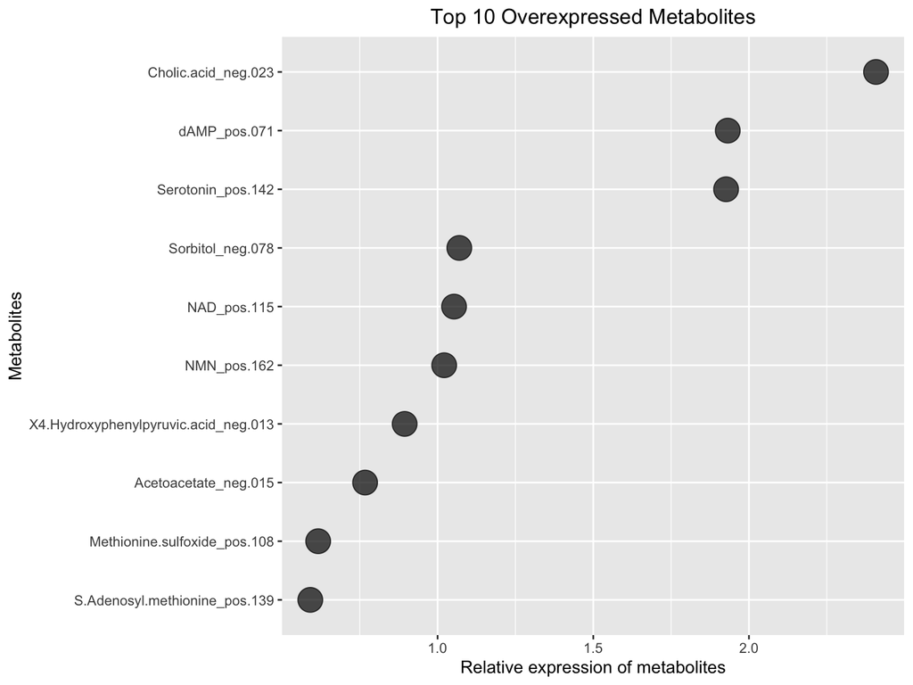

```r
top_expressed <- df_metabolome_summary[order(-df_metabolome_summary$log_relative_expression),][1:10,]

ggplot(top_expressed, aes(x = log_relative_expression, y = reorder(rownames(top_expressed), log_relative_expression))) +
  geom_point(alpha = 0.7, size = 7) +
  labs(
    x = "Relative expression of metabolites",
    y = "Metabolites",
    title = "Top 10 Overexpressed Metabolites"
  ) +
  theme(
    plot.title = element_text(hjust=0.5),
    axis.title.x = element_text(hjust=0.5),
    axis.title.y = element_text(hjust=0.5)
  )
```

# Results: Evaluating mean and sd of top 10 overexpressed metabolites by stage of cancer

For top 10 overexpressed metabolites, I want to explore if there is any change in expression by stage of disease. My hypothesis here is that certain overexpressed metabolites progress linearly as the disease progresses.

To examine if certain metabolites are increasing with more advanced disease states, I first calculate the mean and standard deviation of the top 10 most overexpressed metabolites by stage of cancer (No cancer, I, II, III, IV)

```r
# Split dfs by patients in different stages of cancer

df_No_cancer <- subset(patient_metabolome, stage_of_disease == "_No_cancer")
df_I <- subset(patient_metabolome, stage_of_disease == "I")
df_II <- subset(patient_metabolome, stage_of_disease == "II")
df_III <- subset(patient_metabolome, stage_of_disease == "III")
df_IV <- subset(patient_metabolome, stage_of_disease == "IV")

# Initializing vectors to store mean of top 10 metabolites by stage of cancer

stage_No_cancer_mean <- numeric()
stage_I_mean <- numeric()
stage_II_mean <- numeric()
stage_III_mean <- numeric()
stage_IV_mean <- numeric()

# Initializing vectors to store SD of top 10 metabolites by stage of cancer

stage_No_cancer_sd <- numeric()
stage_I_sd <- numeric()
stage_II_sd <- numeric()
stage_III_sd <- numeric()
stage_IV_sd <- numeric()


# Loop through the top 10 most expressed genes
for (i in 1:10) {
  metabolite <- row.names(top_expressed)[i]

  # Mean by cancer stage
  stage_No_cancer_mean <- append(stage_No_cancer_mean, mean(df_No_cancer[[metabolite]], na.rm = TRUE))
  stage_I_mean <- append(stage_I_mean, mean(df_I[[metabolite]], na.rm = TRUE))
  stage_II_mean <- append(stage_II_mean, mean(df_II[[metabolite]], na.rm = TRUE))
  stage_III_mean <- append(stage_III_mean, mean(df_III[[metabolite]], na.rm = TRUE))
  stage_IV_mean <- append(stage_IV_mean, mean(df_IV[[metabolite]], na.rm = TRUE))

  # SD by cancer stage

  stage_No_cancer_sd <- append(stage_No_cancer_sd, sd(df_No_cancer[[metabolite]], na.rm = TRUE))
  stage_I_sd <- append(stage_I_sd, sd(df_I[[metabolite]], na.rm = TRUE))
  stage_II_sd <- append(stage_II_sd, sd(df_II[[metabolite]], na.rm = TRUE))
  stage_III_sd <- append(stage_III_sd, sd(df_III[[metabolite]], na.rm = TRUE))
  stage_IV_sd <- append(stage_IV_sd, sd(df_IV[[metabolite]], na.rm = TRUE))

}

# Add means and standard deviation of top 10 overexpressed metabolites to top_expressed dataframe

top_expressed$stage_mean__No_cancer <- stage_No_cancer_mean
top_expressed$stage_mean_I <- stage_I_mean
top_expressed$stage_mean_II <- stage_II_mean
top_expressed$stage_mean_III <- stage_III_mean
top_expressed$stage_mean_IV <- stage_IV_mean

top_expressed$stage_sd__No_cancer <- stage_No_cancer_sd
top_expressed$stage_sd_I <- stage_I_sd
top_expressed$stage_sd_II <- stage_II_sd
top_expressed$stage_sd_III <- stage_III_sd
top_expressed$stage_sd_IV <- stage_IV_sd
```

# Results: Identifying metabolites that increase relative expression by stage of disease

Creating a line chart of the top most overexpressed metabolites to see if there are any metabolites that show increased expression relative to the stage of the disease (e.g., the later staged of cancer patients have higher expression of a certain metabolite compared to earlier staged cancer patient)

S.adenosyl.methionine and Sorbitol are two metabolites who’s expression seems to more strongly expressed in patients in later stages of cancers vs earlier stages of cancer

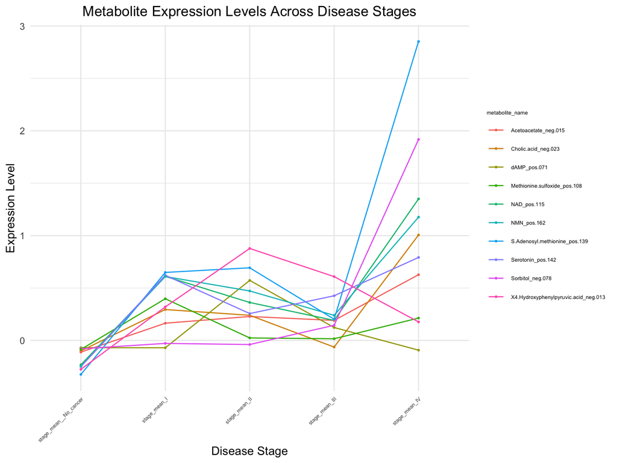

```r
# Making the rownames (which are the names of the expressed metabolites) a column in the "top_expressed" data frame

top_expressed$metabolite_name <- row.names(top_expressed)

#To easily make line chart, I am creating a subset of the "top_expressed" data frame to only having the mean & sd by stage of cancer and the name of the metabolites

stage_cancer_top_expressed <- top_expressed[,8:18]

# Reshape the data from wide format to long format

top_expressed_long <- stage_cancer_top_expressed %>%
  pivot_longer(cols = starts_with("stage_mean_"),
               names_to = "Stage",
               values_to = "Expression")

# Create the line plot using ggplot2

ggplot(top_expressed_long, aes(x = Stage, y = Expression, group = metabolite_name, color = metabolite_name)) +
  geom_line(size = 0.5) +              # Line plot for each metabolite
  geom_point(size = 0.5) +             # Add points to the lines
  labs(title = "Metabolite Expression Levels Across Disease Stages",
       x = "Disease Stage",
       y = "Expression Level") +
  theme_minimal() +
  theme(axis.text.x = element_text(angle = 45, hjust = 1, size = 5),
    plot.title = element_text(hjust=0.5),
    axis.title.x = element_text(hjust=0.5),
    axis.title.y = element_text(hjust=0.5),
    legend.title = element_text(size = 5),
    legend.text = element_text(size = 5),
    legend.spacing.y = unit(0.1, "cm")
  )
```

# Results: Evaluating S.adenosyl.methionine by stage of cancer

To further explore S.adenosyl.methionine, a metabolites who’s expression seems to more strongly expressed in patients in later stages of cancers vs earlier stages of cancer, I constructed a bar chart to understand the expression change by stage of cancer

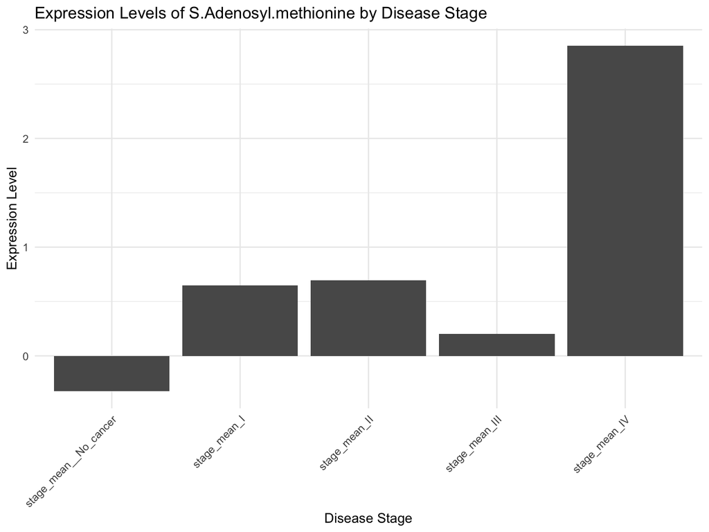

```r
#Create dataframe with just S.adenosyl.methionine

# Filter for the specific metabolite
df_metabolite1 <- top_expressed_long %>%
  filter(metabolite_name == "S.Adenosyl.methionine_pos.139")

# Create the bar chart
ggplot(df_metabolite1, aes(x = Stage, y = Expression)) +
  geom_bar(stat = "identity") +
  labs(title = "Expression Levels of S.Adenosyl.methionine by Disease Stage",
       x = "Disease Stage",
       y = "Expression Level") +
  theme_minimal() +
  theme(axis.text.x = element_text(angle = 45, hjust = 1))
```

# Results: Evaluating coexpression of metabolites in cancer vs healthy patients

Cancer cells frequently undergo metabolic reprogramming. Cancer cells often have altered metabolic pathways compared to healthy cells. This can lead to different patterns of correlations between metabolites. For example, some metabolites might be more strongly correlated in cancer patients due to shared pathways or disruptions in normal metabolic regulation

I wanted to explore potential signs of reprogramming by examining the relationships between expression of metabolites comparing cancer patients to normal patients.

# Results: Heatmap of coexpression of metabolites in cancer vs healthy patients

In order to explore this, I examined a heat map of the correlation (using Pearson) between metabolites for cancer patients and for normal patients. One heatmap for correlation in cancer patients and separate heatmap for healthy patients

The two heat maps have differences in areas where there appear to be stronger and weaker correlation between metabolites

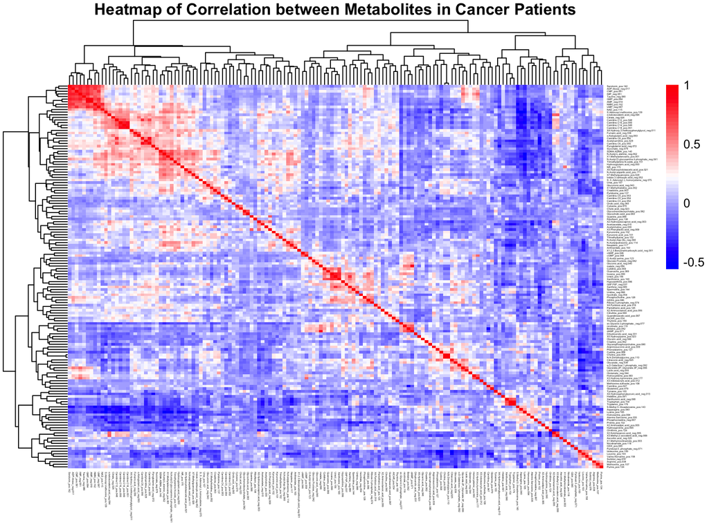

```r
# Isolating the numeric columns (columns containing values for the metabolome measurements) for original cancer and normal patient dataframes

num_cols_cancer_metabolome_og <- cancer_metabolome_og %>%
  select_if(is.numeric)

num_cols_healthy_metabolome_og <- healthy_metabolome_og %>%
  select_if(is.numeric)

# Creating heatmap of correlation between metabolites in cancer patients

cor_matrix_cancer <- cor(num_cols_cancer_metabolome)

pheatmap(cor_matrix_cancer,
         color = colorRampPalette(c("blue", "white", "red"))(50),
         main = "Heatmap of Correlation between Metabolites in Cancer Patients",
         fontsize_col = 2,
         fontsize_row = 2)
```

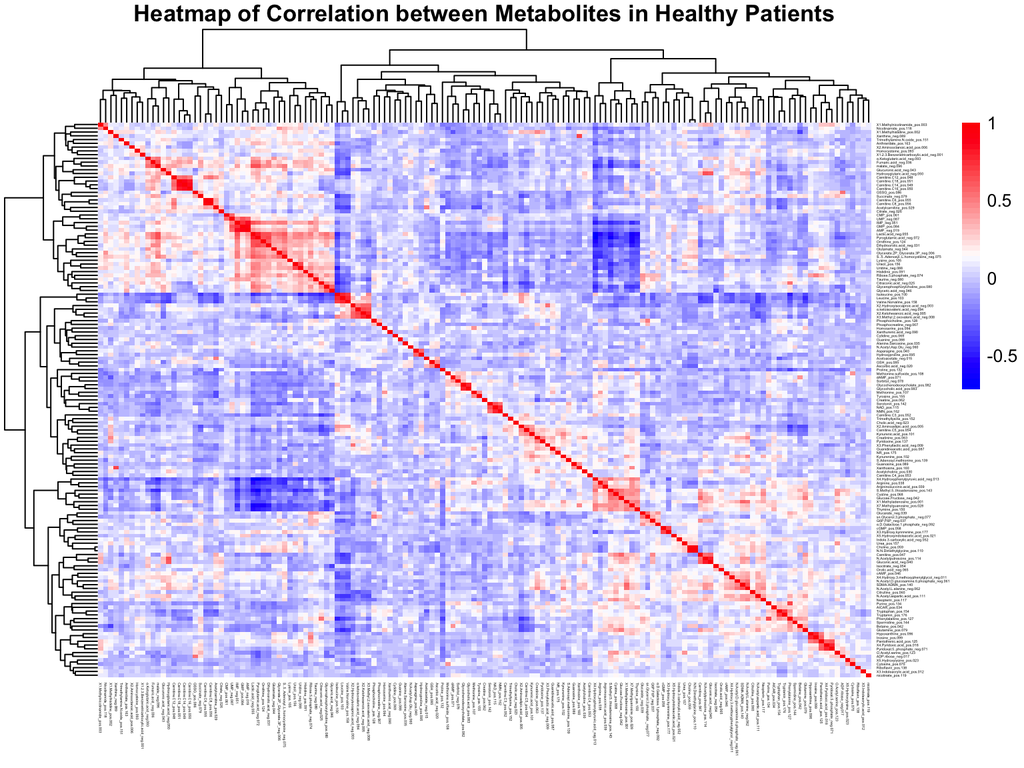

```r
# Creating heatmap of correlation between metabolites in healthy patients

cor_matrix_healthy <- cor(num_cols_healthy_metabolome)

pheatmap(cor_matrix_healthy,
         color = colorRampPalette(c("blue", "white", "red"))(50),
         main = "Heatmap of Correlation between Metabolites in Healthy Patients",
         fontsize_col = 2,
         fontsize_row = 2)
```

# Results: Evaluating differences in signficantly coexpressed metabolites between cancer and healthy patients

From the heatmaps it seems like there are different sets of metabolites that are coorelated between the cancer patients and normal patients.

The hypothesis here is that in healthy individuals, metabolic pathways are well-regulated and function optimally to maintain homeostasis, and the metabolites would reflect that. In cancer patients, cancer cells typically have altered energy metabolism, such as increased glycolysis and changes in amino acid metabolism

The next test I run is looking to how many metabolite combinations yield a significant correlation in cancer patients but not in healthy patients, and vice versa

There are 3132 combination of metabolites where the correlation between two metabolites is significant for cancer patients but not for healthy patients, or vice versa

```r
# Initialize a list to store name of combination of metabolites that are significantly correlated in cancer patients but not healthy patients, and vice versa

results_correlation <- list()

max_difference <- 0
max_diff_names <- list()

metabolite_names <- colnames(num_cols_cancer_metabolome_og)

# Nested for loop to iterate over each pair of metabolite calculating the pearson correlation and then finding the p value

for (i in 1:(length(metabolite_names) - 1)) {
  for (j in (i + 1):length(metabolite_names)) {
    metabolite1 <- metabolite_names[i]
    metabolite2 <- metabolite_names[j]

    # Perform correlation test for cancer patients
    test_result_cancer <- cor.test(num_cols_cancer_metabolome_og[[metabolite1]], num_cols_cancer_metabolome_og[[metabolite2]])

    p_value_cancer <- ifelse(test_result_cancer$p.value < 0.01, "Significant", "Not Significant")

    # Perform correlation test for healthy patients
    test_result_healthy <- cor.test(num_cols_healthy_metabolome_og[[metabolite1]], num_cols_healthy_metabolome_og[[metabolite2]])

    p_value_healthy <- ifelse(test_result_healthy$p.value < 0.01, "Significant", "Not Significant")

    diff_p_value <- abs(test_result_cancer$p.value - test_result_healthy$p.value)

    # If there is a mismatch in significance, then store the value in results

    if (p_value_cancer != p_value_healthy) {
      combo <- c(metabolite1,metabolite2)
      results_correlation <- append(results_correlation, list(combo))

      #find biggest difference in p values
      if (diff_p_value > max_difference) {
        max_difference <- diff_p_value
        max_diff_names <- list(combo)
      }
    }
  }
}

print(paste0("There are ", length(results_correlation), " combination of metabolites where the correlation between two metabolites is significant for cancer patients but not for healthy patients, or vice versa"))
```

```
## [1] "There are 3132 combination of metabolites where the correlation between two metabolites is significant for cancer patients but not for healthy patients, or vice versa"
```

# Results: Exploring relationship between Arginine.038 and Pyroglumatic acid.072 in cancer patients vs healthy patients

To demonstrate the difference in significance in correlation in two metabolites in cancer patients vs healthy patients, I use a scatterplot to explore the relationships of metabolites that have the highest degree of difference in p value between cancer patients and healthy patients.

The two metabolites with the greatest difference in p values between healthy and cancer patients are Arginine.038 and Pyroglumatic acid.072. There is a significant correlation between these two metabolites for healthy patients (p value is 1.23e-16) and no significant correlation between these metabolites for cancer patients (p value is 0.99)

```r
# Two metabolites that have varying significance between cancer and healthy patients

metabolite1 <- max_diff_names[[1]][[1]]
metabolite2 <- max_diff_names[[1]][[2]]

print(metabolite1)
```

```
## [1] "Arginine_pos.038"
```

```r
print(metabolite2)
```

```
## [1] "Pyroglutamic.acid_neg.072"
```

```r
# The correlation value for metabolite 1 and 2 in cancer patients vs healthy patients

test_result_cancer <- cor.test(num_cols_cancer_metabolome_og[[metabolite1]], num_cols_cancer_metabolome_og[[metabolite2]])

p_value_cancer <- test_result_cancer$p.value

test_result_healthy <- cor.test(num_cols_healthy_metabolome_og[[metabolite1]], num_cols_healthy_metabolome_og[[metabolite2]])

p_value_healthy <- test_result_healthy$p.value

print(p_value_cancer)
```

```
## [1] 0.9990708
```

```r
print(p_value_healthy)
```

```
## [1] 1.227387e-16
```

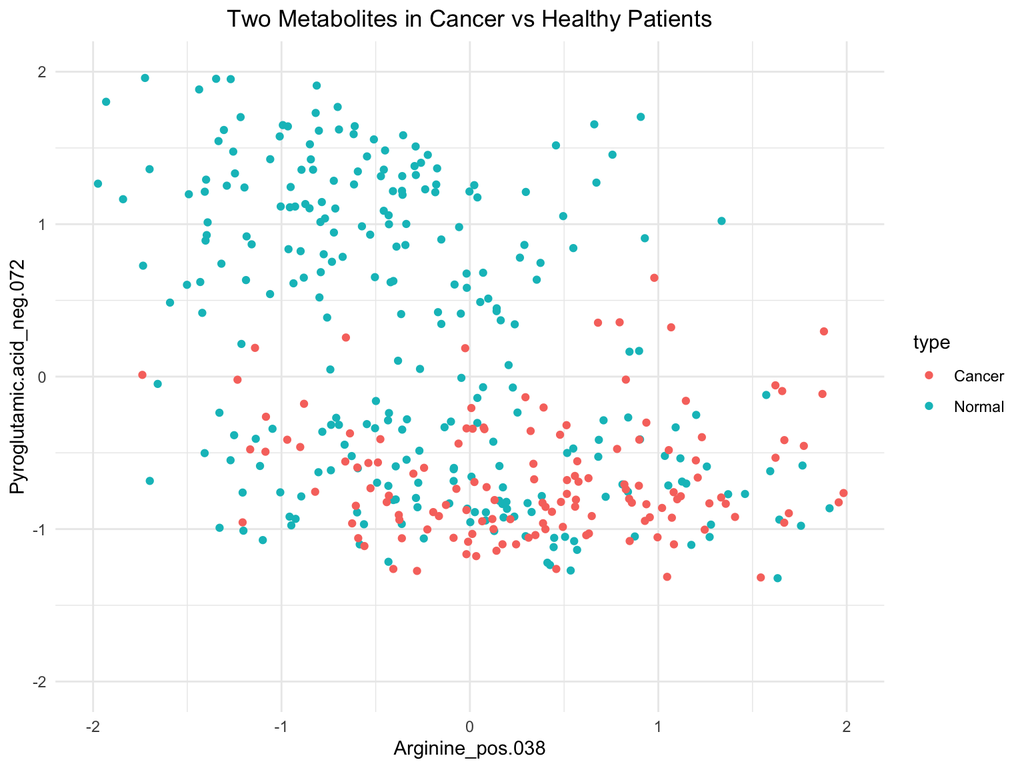

```r
# Creating scatterplot of metabolites and labeling based on health status

ggplot(patient_metabolome, aes(x= Arginine_pos.038, y = Pyroglutamic.acid_neg.072, color = type))+
  geom_point() +
  labs(title = "Two Metabolites in Cancer vs Healthy Patients") +
  theme_minimal()+
  xlim(-2,2)+
  ylim(-2,2)+
  theme(plot.title = element_text(hjust=0.5))
```

# Discussion / Future direction

Based on this analysis, metabolic pathways appear to be significantly perturbed in cancer patients. There appears to be significant differences in expression of metabolites in cancer and healthy patients (96 metabolites are difficantly different), in coexpression patterns of metabolites and differences in expression by stage of cancer.

In this project, I explored the differences in metabolite expression by stage of cancer but would run significance tests and regression tests to further understand how metabolites correspond to a patient’s stage of cancer

Additionally, in this analysis, I independently examine 147 metabolites. In the future, these metabolites could be annotated by their relative function. Using the Kyoto Encylopedia of Genes and Genomes metabolic pathways, metabolites can be grouped by key pathways and expression levels can be summed. Statistical tests can be run to evalaute if significant changes occur at a pathway level vs a metabolite level

# Work Cited

Chen Y, Wang B, Zhao Y, Shao X, Wang M, Ma F, Yang L, Nie M, Jin P, Yao K, Song H, Lou S, Wang H, Yang T, Tian Y, Han P, Hu Z. Metabolomic machine learning predictor for diagnosis and prognosis of gastric cancer. Nat Commun. 2024 Feb 23;15(1):1657. doi: 10.1038/s41467-024-46043-y.